# Dead wood stocks and fluxes for Barro Colorado Island 50-ha forest dynamic plot, 2017-2024

Lily Pitcher and Helene C. Muller-Landau

2025-04-13

### Citation and License

It is licensed under CC BY 4.0.

### Contributions and Acknowledgments

Lily Pitcher conducted data cleaning, performed the analyses and wrote this Rmarkdown report. Helene C. Muller-Landau co-designed the study, supervised the field work, supervised the analyses, and edited the report. Pablo Ramos and Paulino Villareal collected the field data. Markku Larjavaara co-designed the study. This work builds on previous data cleaning and analyses by Evan Gora (see in Gora et al. 2019). This study was funded by Smithsonian ForestGEO and the HSBC Climate Partnership.

### Study site and sample design

This document reports the estimated above ground deadwood stocks of dead trees in the 50ha plot of Barrow Colorado Island, STRI, Panama. Woody debris is estimated for 100 (40X40m) within the 50ha through annual field studies which comprised of the following studies:

Fine Woody Debris (FWD) dynamics: FWD is deadwood with a diameter from 20-199mm.FWD is only censused within the central area of the subplot with a radius of 5m. Diameter and height are measured on every piece encountered. We try to record the tag. Plots are inventoried repeatedly every 12 months, to provide data on input and output as well as on stocks and temporal variation Further details of sampling design and protocols can be found here:

https://forestgeo.si.edu/protocols/woody-debris

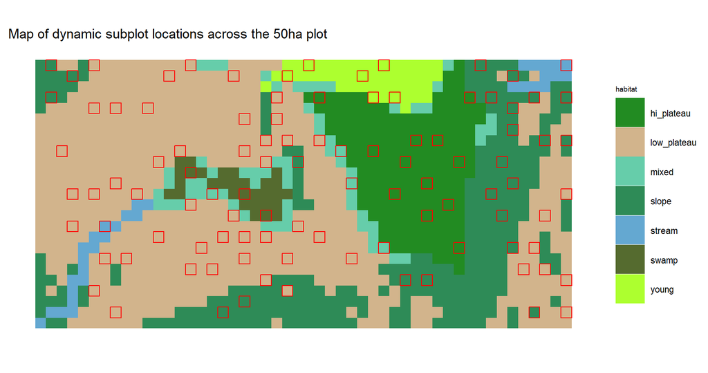

Map showing the dynamic subplots across the 50ha plot

| Summary of Annual CWD census Year | Summary of Annual CWD census Start Date | Summary of Annual CWD census End Date | Summary of Annual CWD census Downed Total pieces | Summary of Annual CWD census Downed New pieces | Summary of Annual CWD census Standing Total pieces | Summary of Annual CWD census Standing New pieces | Summary of Annual CWD census People involved |
| --- | --- | --- | --- | --- | --- | --- | --- |
| 2017 | 23 January | 02 March | 257 | 257 | 142 | 142 | R |
| 2018 | 24 January | 15 March | 248 | 59 | 136 | 40 | R |
| 2019 | 17 January | 28 February | 272 | 60 | 131 | 31 | E, R |
| 2020 | 03 February | 06 March | 247 | 46 | 130 | 42 | R, V |
| 2021 | 22 February | 10 March | 234 | 49 | 140 | 45 | E, R, V |
| 2022 | 07 February | 22 February | 235 | 45 | 133 | 41 | E, V |
| 2023 | 08 February | 13 March | 227 | 46 | 128 | 26 | E, R, V |
| 2024 | 02 February | 14 March | 232 | 41 | 102 | 20 | E, V |

**Table1**

Summary of census effort for each yearcol including census period (start and end date), total number of pieces of wood measured each yearcol for Downed and Standing (Total Pieces) and the number of new pieces of dead wood (New pieces). Initials represent the following people involved in the sample collection: R:Pablo Ramos, V:Paulino Villarreal and E is both working as a team.

### Calculations of CWD stores and fluxes

This report calculates yearly stores and fluxes of standing and downed Coarse woody debris. The data has been formatted, cleaned and processed prior to loading loading into this report. Pre calculations have been made on individual sample pieces, code can be found in **density_calculation_bci50deadwood_correctedtoprocessed.Rmd** and explanations of all calculations done in **density_calculation_bci50deadwood_correctedtoprocessed.Rmd** as well as this report can be found in **calcexplanation_bci50deadwood_stocks&fluxes.Rmd**.

### Total estimates for CWD stocks, fluxes and residence time for BCI 50ha plots

| Coarse Woody Debris Summary Statistics Mean Total Mass (Mg ha<sup>-1</sup>) | Coarse Woody Debris Summary Statistics Mean Input Mass (Mg ha<sup>-1</sup>y<sup>-1</sup>) | Coarse Woody Debris Summary Statistics Mean Total Volume (m<sup>3</sup> ha<sup>-1</sup>) | Coarse Woody Debris Summary Statistics Mean Input Volume (m<sup>3</sup> ha<sup>-1</sup> y<sup>-1</sup>) | Coarse Woody Debris Summary Statistics Residence time (y<sup>-1</sup>) |
| --- | --- | --- | --- | --- |
| **Downed** |  |  |  |  |
| 10.15 | 10.15 | 38.15 | 38.15 | 1 |
| **Standing** |  |  |  |  |
| 6.82 | 6.82 | 13.85 | 13.85 | 1 |

**Table 2**

### Annual variation in woody debris stocks and fluxes

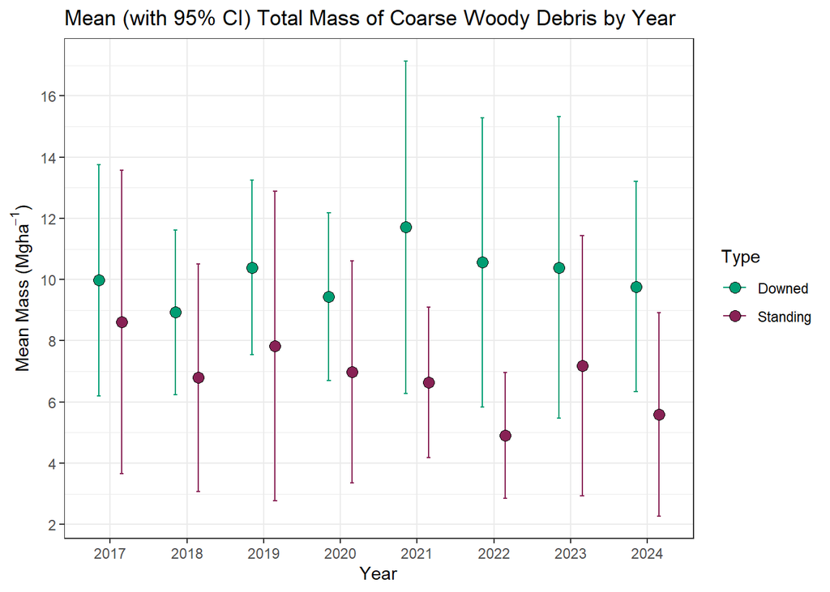

**Figure 1**

Annual variability in estimated downed and standing CWD stocks as Mass with 95% confidence intervals. Colored points represent the mean(CI95%) total Mass of CWD for each yearcol.

[figure not shown]

**Figure 2**

Annual variability in estimated downed and standing CWD stocks as Volume with 95% confidence intervals. Colored points represent the mean(CI95%) total volume of CWD for each yearcol.

### Distribution of CWD stocks and fluxes across the dynamic subplots

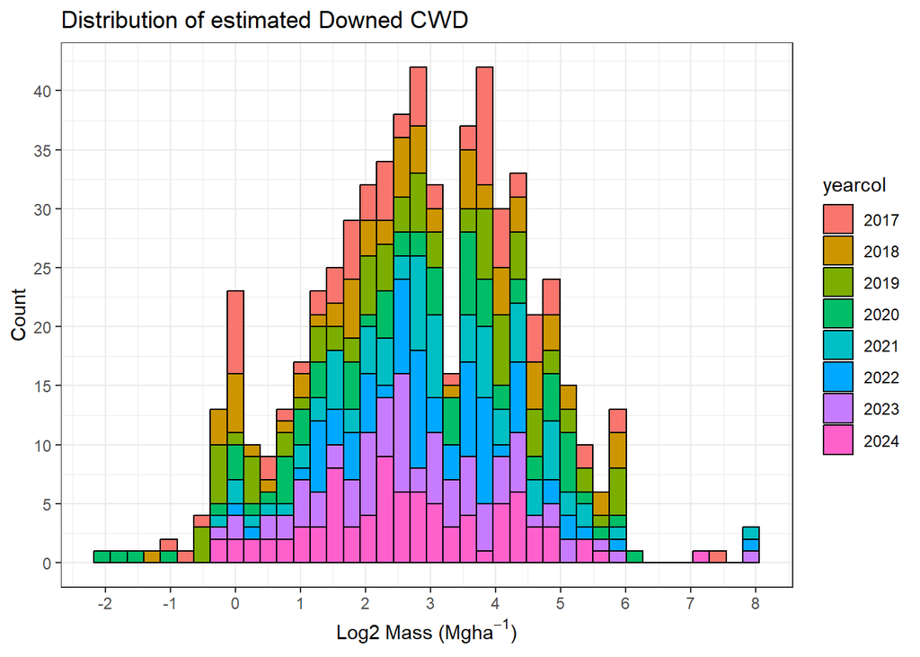

**Figure 3**

Distribution of log base 2 estimated total downed CWD Mass for each subplot, coloured by yearcol. Count represents the number of subplots which have an estimated Mass of downed CWD within that range of the x-axis.

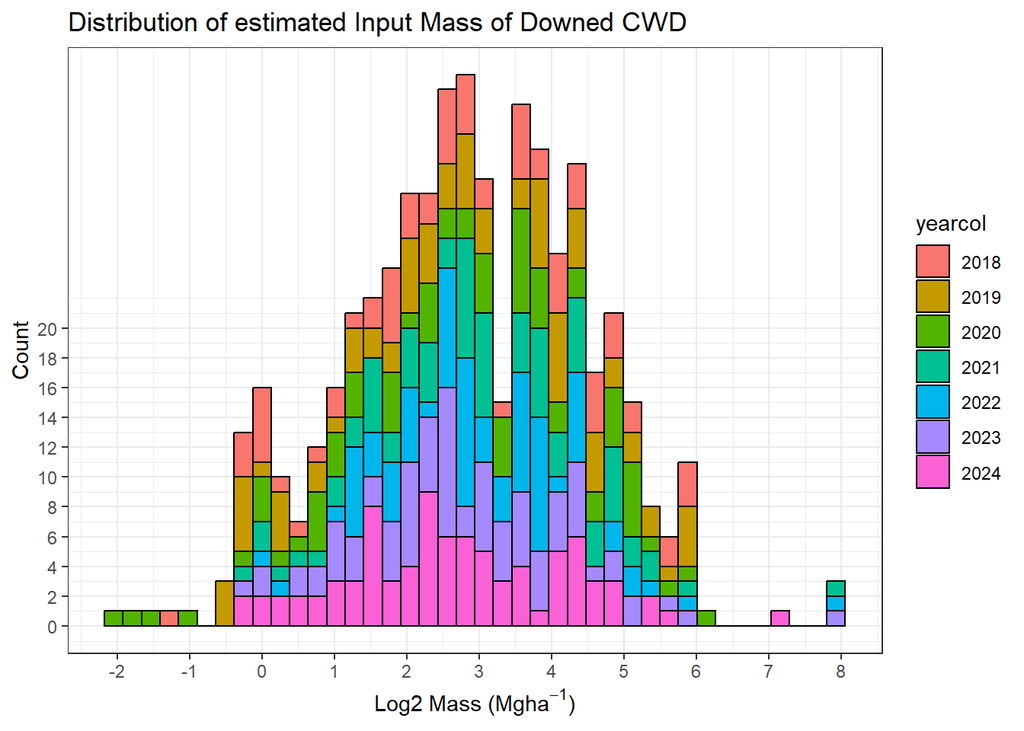

**Figure 4**

Distribution of log base 2 estimated inputs of downed CWD Mass for each subplot, coloured by yearcol. Count represents the number of subplots which have an estimated Mass of downed CWD within that range of the x-axis.

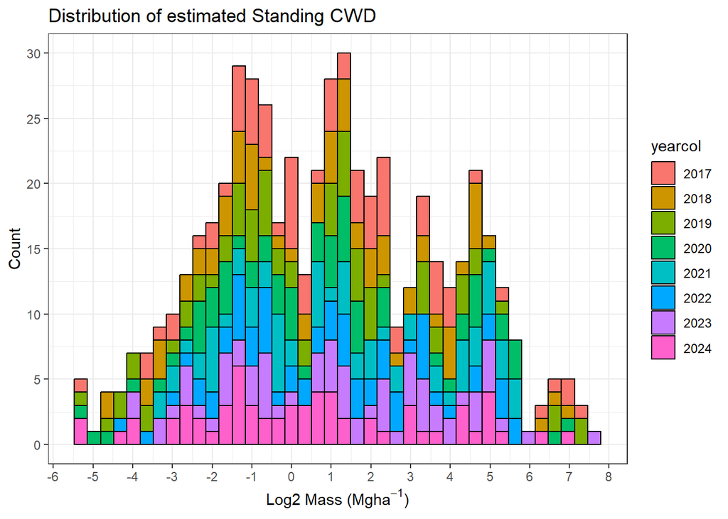

**Figure 5**

Distribution of log base 2 estimated total standing CWD Mass for each subplot, coloured by yearcol. Count represents the number of subplots which have an estimated Mass of standing CWD within that range of the x-axis.

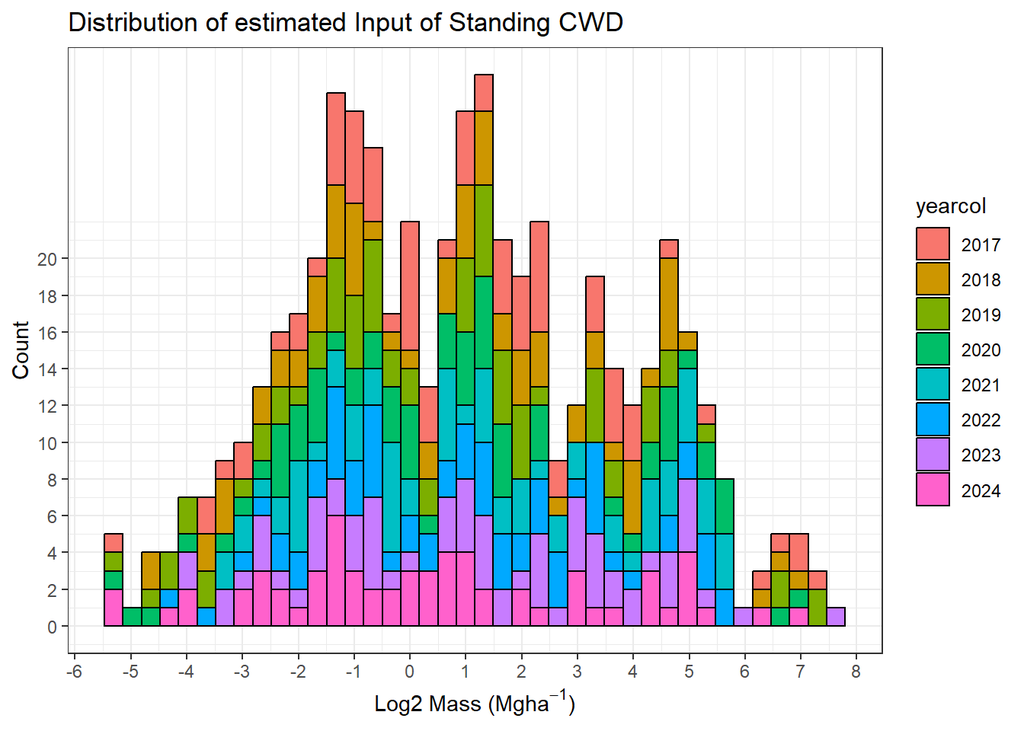

**Figure 6**

### Variation in CWD stocks and fluxes over time within subplots

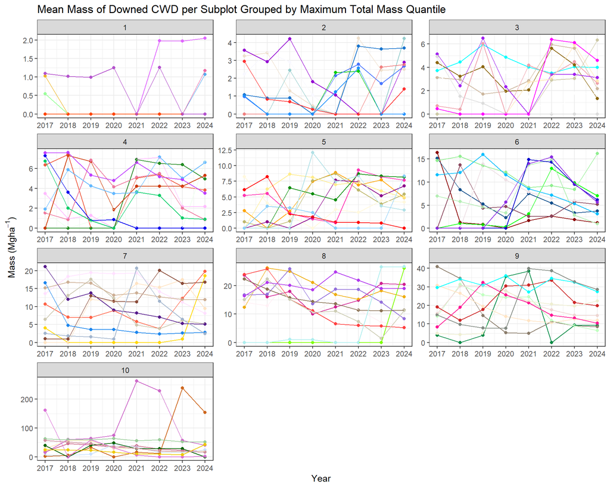

**Figure 7**

Annual variation in estimated downed coarse woody debris (CWD) mass for each 40×40 m dynamic subplot, grouped by total mass quantile

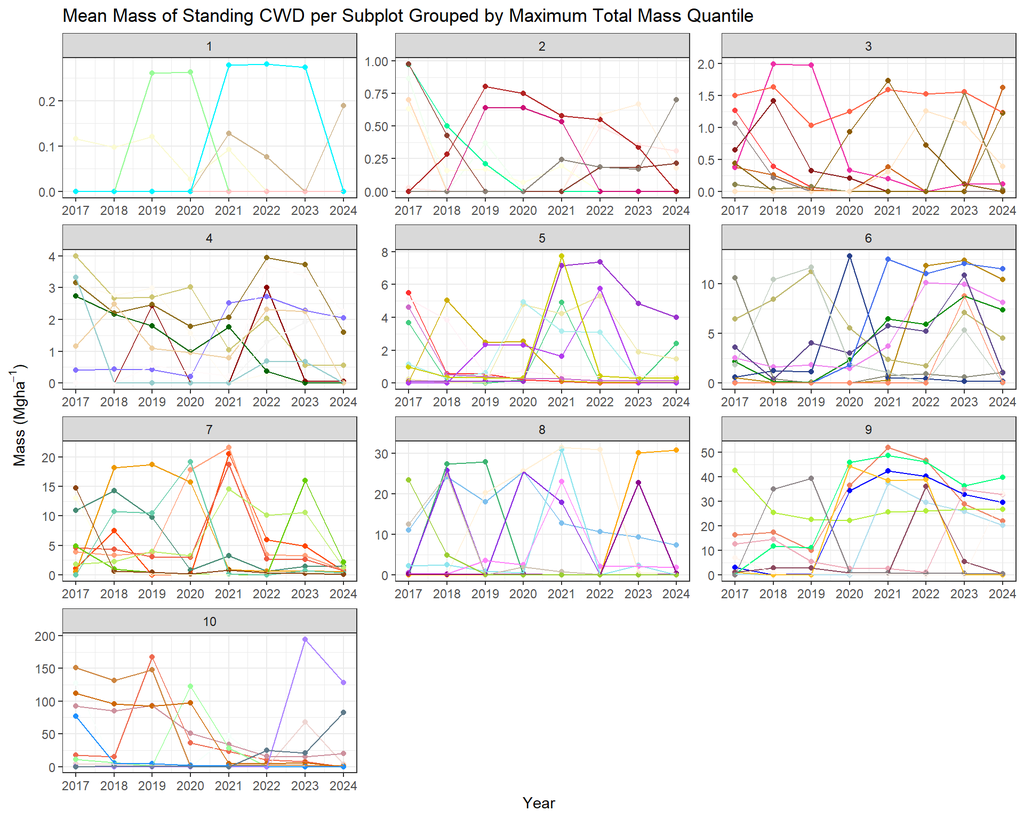

**Figure 8**

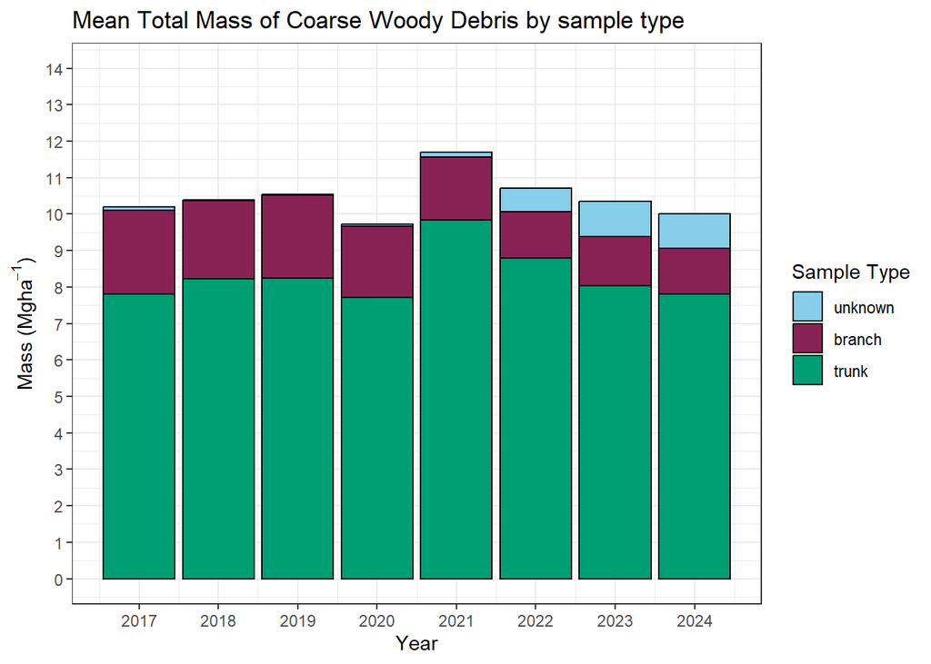

**Figure 9**

rmarkdown::render(“report_bci50CWD_2009-24v2.Rmd”, output_file = “Output/report_bci50CWD_2017-24v2.html”)